# Arrests and Calls for Service in Baltimore

## From Where in the City do Calls Originate?

Unlike the Arrest dataset, the city’s Calls for Service dataset does not contain a variable identifying the neighborhood associated with the call. However, since each call for service includes approximate coordinates for the related incident, we are able to overlay the city’s neighborhood shapefile and the Census tract shapefile to get a sense of the geographic distribution of calls.

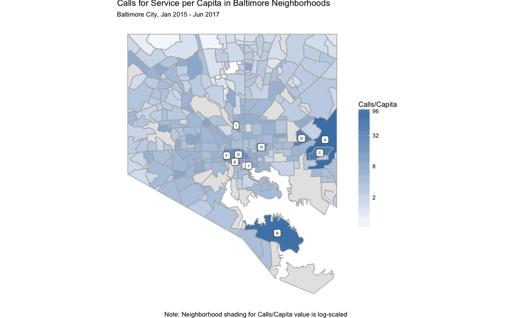

```r
TopCallNeighborhoods <- NeighborhoodDf %>%
  filter(!is.infinite(CallsForServicePerCapita)) %>%
  arrange(desc(CallsForServicePerCapita)) %>%
  head(10) %>%
  bind_cols(tibble(KeyAbbr=c(LETTERS[1:(nrow(.))]))) %>%
  select(KeyAbbr, Name, CallsForServicePerCapita, CallsForService, Population, CentroidLongitude, CentroidLatitude)
NeighborhoodSDF %>%
  ggplot(mapping=aes(x=long, y=lat, group=group)) +
    geom_polygon(aes(fill=CallsForServicePerCapita)) +
    geom_path(color='grey70') +
    geom_label(data=TopCallNeighborhoods,
               mapping=aes(x=CentroidLongitude, y=CentroidLatitude, label=KeyAbbr),
               inherit.aes=FALSE, size=2) +
    scale_fill_gradient(low = "white",high = "steelblue", na.value='grey90', trans='log', breaks=c(2,8,32,96)) +
    coord_map() +
    theme_void() +
  theme(legend.key.height=unit(2.5, 'line'), legend.title.align=0.5) +
  labs(fill='Calls/Capita',
       title='Calls for Service per Capita in Baltimore Neighborhoods',
       caption='Note: Neighborhood shading for Calls/Capita value is log-scaled',
       subtitle=paste0('Baltimore City, ', minDateS, ' - ', maxDateS))
```

Similar to the distribution of arrests per capita as seen in the prior analysis, calls for service (on a per capita basis) are significantly higher in the industrial areas, not because there are significantly more calls in those areas, but because there are fewer residents living there. Note that we use a log scale for the color gradient in this choropleth map, to reduce the impact of the outliers on the gradient.

The ten neighborhoods with the highest per-capita calls over this two-and-a-half year period, are:

```r
kable(TopCallNeighborhoods %>%
        select(Label=KeyAbbr, Neighborhood=Name, CallsForService, Population, `Calls per Capita`=CallsForServicePerCapita) %>%
        mutate(`Calls per Capita`=comma(`Calls per Capita`), `Calls for Service`=comma(CallsForService), Population=comma(Population)) %>%
        select(-CallsForService), format='html'
) %>% kable_styling(bootstrap_options = c("striped", "hover", "condensed"))
```

| Label | Neighborhood | Population | Calls per Capita | Calls for Service |
| --- | --- | --- | --- | --- |
| A | Pulaski Industrial Area | 123 | 135.14634 | 16,623 |
| B | Fairfield Area | 159 | 114.71698 | 18,240 |
| C | Hopkins Bayview | 103 | 66.68932 | 6,869 |
| D | Orangeville | 202 | 51.35644 | 10,374 |
| E | Downtown West | 366 | 45.35519 | 16,600 |
| F | University Of Maryland | 387 | 30.36693 | 11,752 |
| G | Downtown | 4,448 | 26.98876 | 120,046 |
| H | Dunbar-Broadway | 889 | 24.65467 | 21,918 |
| I | Charles North | 1,059 | 14.73560 | 15,605 |
| J | Inner Harbor | 1,484 | 12.36725 | 18,353 |

Aggregating calls per capita by Census tract indicates that calls per capita (like arrests per capita) are highest in the downtown area, and slightly less so to the immediate west of downtown and in the Pulaski area:

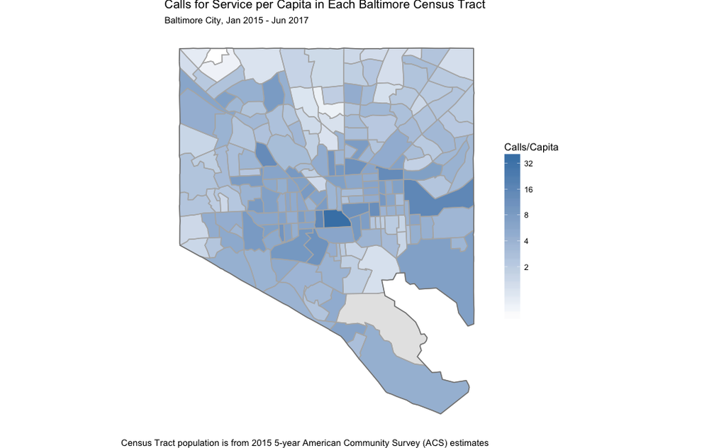

```r
CensusBlockSDF %>%
  ggplot(mapping=aes(x=long, y=lat, group=group)) +
    geom_polygon(aes(fill=CallsForServicePerCapita)) +
    geom_path(color='grey70') +
    geom_path(data=CountySDF, color='grey50') +
    scale_fill_gradient(low = "white",high = "steelblue", na.value='grey90', labels=comma, trans='log', breaks=c(2,4,8,16,32)) +
    coord_map() +
    theme_void() +
  theme(legend.key.height=unit(2.5, 'line'), legend.title.align=0.5) +
  labs(fill='Calls/Capita',
       title='Calls for Service per Capita in Each Baltimore Census Tract',
       caption='Census Tract population is from 2015 5-year American Community Survey (ACS) estimates',
       subtitle=paste0('Baltimore City, ', minDateS, ' - ', maxDateS))
```

## Do Demographic and Economic Factors Correlate with Call Volume?

Citywide, over the time period covered by this dataset, there were 3.92 calls for service per capita. It is fair to ask whether this citywide average is significantly different across a spectrum of demographic and economic characteristics by area. In the following scatterplots, we see that the percentage of Census tract population that is white, the median age, and the tract’s median household income are all negatively correlated with service calls per capita (though the strength of the correlation varies somewhat across these explanatory variables).

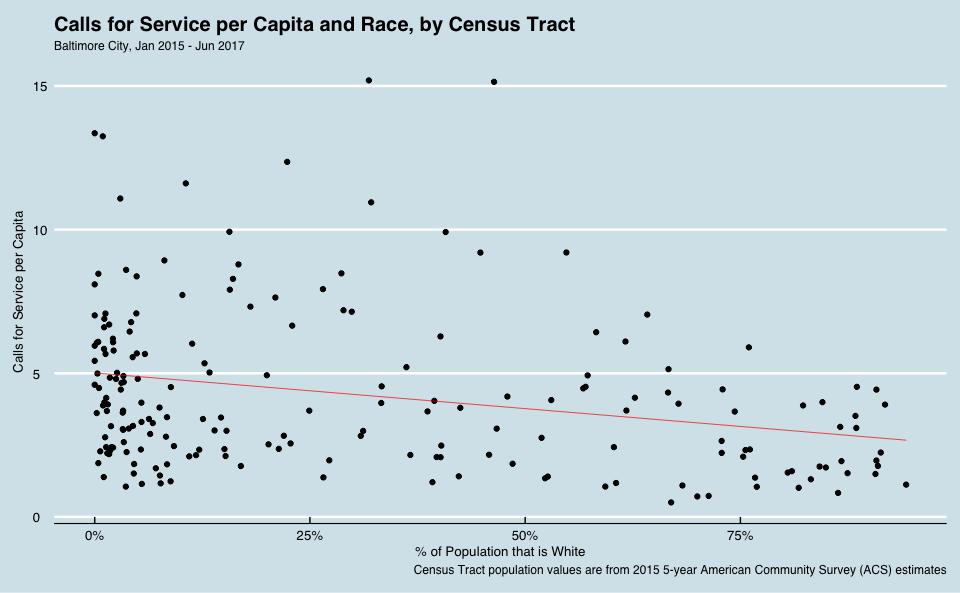

```r
ggplot(data=CensusBlockDf %>% filter(CallsForServicePerCapita < 30)) +
  geom_point(mapping=aes(x=PercentWhite, y=CallsForServicePerCapita), na.rm=TRUE) +
  geom_smooth(mapping=aes(x=PercentWhite, y=CallsForServicePerCapita), na.rm=TRUE,
              method='lm', color='red', size=.25, se=FALSE) +
    scale_x_continuous(labels=percent) +
  labs(title='Calls for Service per Capita and Race, by Census Tract',
       x='% of Population that is White', y='Calls for Service per Capita',
       subtitle=paste0('Baltimore City, ', minDateS, ' - ', maxDateS),
       caption='Census Tract population values are from 2015 5-year American Community Survey (ACS) estimates') +
  theme_economist()
```

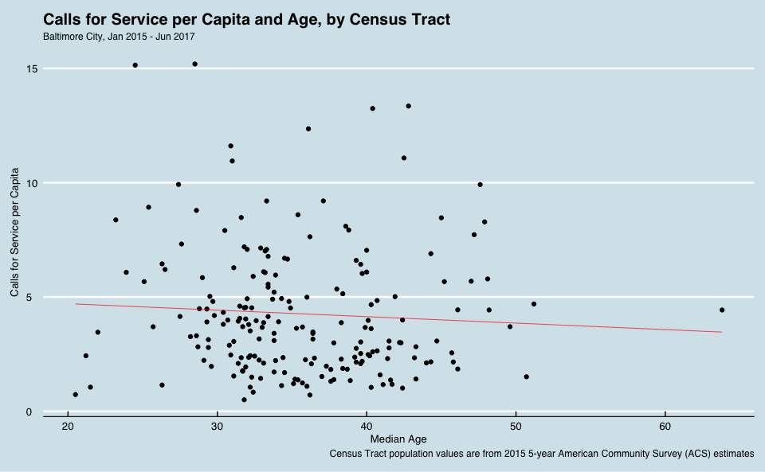

```r
ggplot(data=CensusBlockDf %>% filter(CallsForServicePerCapita < 30)) +
  geom_point(mapping=aes(x=MedianAge, y=CallsForServicePerCapita), na.rm=TRUE) +
  geom_smooth(mapping=aes(x=MedianAge, y=CallsForServicePerCapita), na.rm=TRUE,
              method='lm', color='red', size=.25, se=FALSE) +
  labs(title='Calls for Service per Capita and Age, by Census Tract',
       x='Median Age', y='Calls for Service per Capita',
       subtitle=paste0('Baltimore City, ', minDateS, ' - ', maxDateS),
       caption='Census Tract population values are from 2015 5-year American Community Survey (ACS) estimates') +
  theme_economist()
```

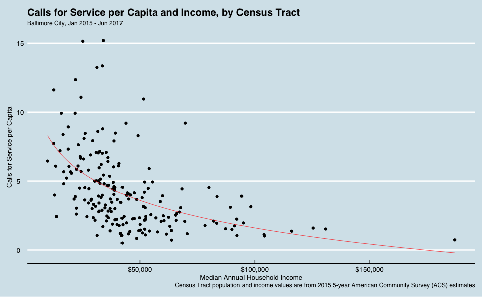

```r
ggplot(data=CensusBlockDf %>% filter(CallsForServicePerCapita < 30)) +
  geom_point(mapping=aes(x=MedianHouseholdIncome, y=CallsForServicePerCapita), na.rm=TRUE) +
  geom_smooth(mapping=aes(x=MedianHouseholdIncome, y=CallsForServicePerCapita), na.rm=TRUE,
              method='lm', formula=y ~ log(x), color='red', size=.25, se=FALSE) +
  scale_x_continuous(labels=dollar) +
  labs(title='Calls for Service per Capita and Income, by Census Tract',
       x='Median Annual Household Income', y='Calls for Service per Capita',
       subtitle=paste0('Baltimore City, ', minDateS, ' - ', maxDateS),
       caption='Census Tract population and income values are from 2015 5-year American Community Survey (ACS) estimates') +
  theme_economist()
```

There is also a correlation between the type of land use, as [classified](http://planning.maryland.gov/OurProducts/downloadFiles.shtml) by the state of Maryland (in 2010), with “more residential” Census tracts exhibiting a relatively lower frequency of calling for service:

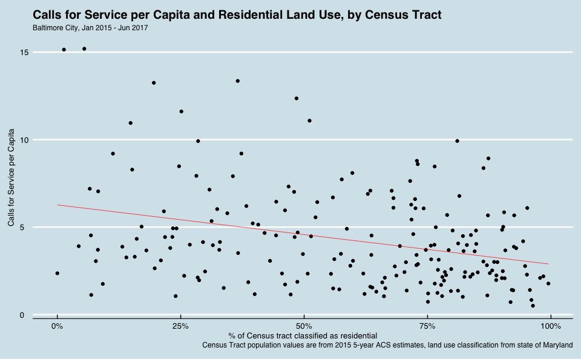

```r
ggplot(data=CensusBlockDf %>% filter(CallsForServicePerCapita < 30)) +
  geom_point(mapping=aes(x=ResidentialPercentage, y=CallsForServicePerCapita), na.rm=TRUE) +
  geom_smooth(mapping=aes(x=ResidentialPercentage, y=CallsForServicePerCapita), na.rm=TRUE,
              method='lm', color='red', size=.25, se=FALSE) +
  scale_x_continuous(labels=percent) +
  labs(title='Calls for Service per Capita and Residential Land Use, by Census Tract',
       x='% of Census tract classified as residential', y='Calls for Service per Capita',
       subtitle=paste0('Baltimore City, ', minDateS, ' - ', maxDateS),
       caption='Census Tract population values are from 2015 5-year ACS estimates, land use classification from state of Maryland') +
  theme_economist()
```

It is worth noting that there is intuitively a high degree of correlation *among* these explanatory variables. To tease out the partial effects, we run a regression model of per-capita Calls for Service on these four variables (taking the log of household income to account for the exponential effect of this variable detected in the visualization above):

```r
model <- lm(data=CensusBlockDf,
   formula=CallsForServicePerCapita ~ log(MedianHouseholdIncome) + ResidentialPercentage + MedianAge + PercentWhite)
model %>%
  tidy() %>%
  select(-statistic) %>%
  mutate(term=case_when(
    grepl(x=term, pattern='Income') ~ 'log(Median HH Income)',
    grepl(x=term, pattern='Residential') ~ '% Residential',
    grepl(x=term, pattern='Age') ~ 'Median Age',
    grepl(x=term, pattern='White') ~ '% White',
    TRUE ~ '(Intercept)'
  )) %>%
kable(format='html', digits=c(0, 2, 2, 3), col.names=c('Variable', 'Estimate', 'Std Error', 'p(>|t|)')) %>%
  kable_styling(bootstrap_options = c("striped", "hover", "condensed"))
```

| Variable | Estimate | Std Error | p(>\|t\|) |
| --- | --- | --- | --- |
| (Intercept) | 37.67 | 6.22 | 0.000 |
| log(Median HH Income) | -2.77 | 0.62 | 0.000 |
| % Residential | -5.09 | 0.85 | 0.000 |
| Median Age | -0.02 | 0.04 | 0.506 |
| % White | -0.06 | 1.01 | 0.951 |

In this model, both income and residential land use proportion are negatively correlated with calls per capita, and are statistically significant. Age and race are not statistically significant, suggesting that the effects of these variables “wash out” when income and land use are included.

## The Relationship Between Calls for Service and Arrests

As discussed in the introduction above, we can potentially learn something interesting about crime and policing in Baltimore by examining the relationship between arrests and calls for service. We do so here by computing the ratio of arrests to calls and looking at how this ratio varies across Census tracts in the city.

Between January 01, 2015 and June 17, 2017, the city-wide ratio of arrests was 0.049, or 4.9 arrests per 100 calls for service. This ratio varies somewhat across the city, however:

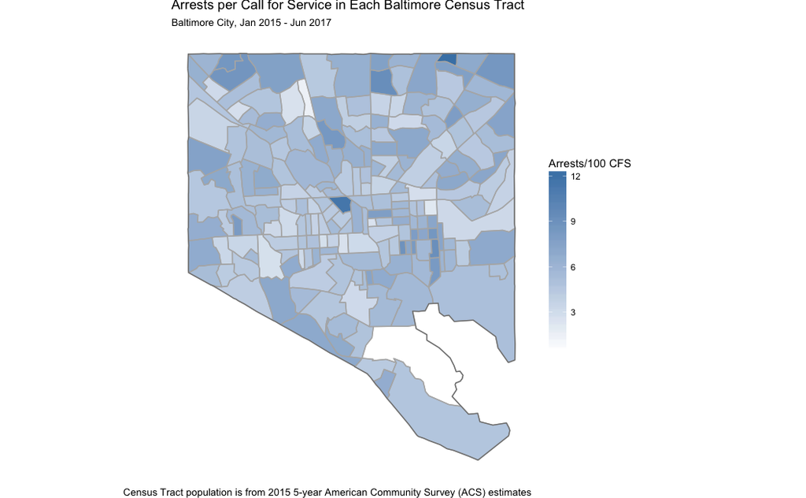

```r
CensusBlockSDF %>%
  mutate(ArrestsPer100CallsForService=100*ArrestsPerCallForService) %>%
  ggplot(mapping=aes(x=long, y=lat, group=group)) +
    geom_polygon(aes(fill=ArrestsPer100CallsForService)) +
    geom_path(color='grey70') +
    geom_path(data=CountySDF, color='grey50') +
    scale_fill_gradient(low = "white",high = "steelblue", na.value='grey90') +
    coord_map() +
    theme_void() +
  theme(legend.key.height=unit(2.5, 'line'), legend.title.align=0.5) +
  labs(fill='Arrests/100 CFS',
       title='Arrests per Call for Service in Each Baltimore Census Tract',
       caption='Census Tract population is from 2015 5-year American Community Survey (ACS) estimates',
       subtitle=paste0('Baltimore City, ', minDateS, ' - ', maxDateS))
```

We can also examine the variation by neighborhood, with the top and bottom five neighborhoods being as follows:

```r
ndf <- bind_rows(
  NeighborhoodDf %>% filter(Population != 0) %>% top_n(5, ArrestsPerCallForService),
  NeighborhoodDf %>% filter(Population != 0) %>% top_n(-5, ArrestsPerCallForService)
) %>% select(Neighborhood=Name, ArrestsPerCallForService, CallsForServicePerCapita, ArrestsPerCapita, Population) %>%
  mutate(ArrestsPerCallForService=100*ArrestsPerCallForService) %>%
  arrange(desc(ArrestsPerCallForService))
kable(ndf %>%
        mutate(`Calls per Capita`=comma(CallsForServicePerCapita, digits=2, nsmall=2),
               `Arrests per Capita`=comma(ArrestsPerCapita, digits=2, nsmall=2),
               `Arrests per 100 CFS`=comma(ArrestsPerCallForService, digits=2, nsmall=2),
               Population=comma(Population, digits=0)) %>%
        select(Neighborhood,
               `Arrests per 100 CFS`,
               `Arrests per Capita`,
               `Calls per Capita`,
               Population), format='html'
) %>% kable_styling(bootstrap_options = c("striped", "hover", "condensed"))
```

| Neighborhood | Arrests per 100 CFS | Arrests per Capita | Calls per Capita | Population |
| --- | --- | --- | --- | --- |
| Hoes Heights | 20.75 | 0.206 | 0.99 | 865 |
| Wyman Park | 12.87 | 0.102 | 0.79 | 1,141 |
| Villages Of Homeland | 12.85 | 0.057 | 0.44 | 562 |
| North Roland Park/Poplar Hill | 11.79 | 0.066 | 0.56 | 1,450 |
| Lake Evesham | 11.54 | 0.149 | 1.29 | 543 |
| Biddle Street | 1.55 | 0.178 | 11.45 | 1,265 |
| Winston-Govans | 1.52 | 0.165 | 10.82 | 1,341 |
| Blythewood | 0.96 | 0.028 | 2.89 | 72 |
| Fairfield Area | 0.89 | 1.019 | 114.72 | 159 |
| Johns Hopkins Homewood | 0.85 | 0.076 | 8.93 | 669 |

By running a similar regression to the one above, but with Arrests per 100 Calls For Service as the dependent variable this time, we can examine the relationships between the ratio and key Census tract characteristics.

```r
model <- lm(data=CensusBlockDf %>%  mutate(ArrestsPerCallForService=100*ArrestsPerCallForService),
   formula=ArrestsPerCallForService ~ log(MedianHouseholdIncome) + ResidentialPercentage + MedianAge + PercentWhite)
model %>%
  tidy() %>%
  select(-statistic) %>%
  mutate(term=case_when(
    grepl(x=term, pattern='Income') ~ 'log(Median HH Income)',
    grepl(x=term, pattern='Residential') ~ '% Residential',
    grepl(x=term, pattern='Age') ~ 'Median Age',
    grepl(x=term, pattern='White') ~ '% White',
    TRUE ~ '(Intercept)'
  )) %>%
kable(format='html', digits=c(0, 3, 3, 3), col.names=c('Variable', 'Estimate', 'Std Error', 'p(>|t|)')) %>%
  kable_styling(bootstrap_options = c("striped", "hover", "condensed"))
```

| Variable | Estimate | Std Error | p(>\|t\|) |
| --- | --- | --- | --- |
| (Intercept) | -1.090 | 2.867 | 0.704 |
| log(Median HH Income) | 0.531 | 0.285 | 0.064 |
| % Residential | 2.324 | 0.394 | 0.000 |
| Median Age | -0.023 | 0.016 | 0.159 |
| % White | 1.193 | 0.463 | 0.011 |

Note that the proportion of residential land use is a significant explanatory variable here, as it was in the regression on calls per capita. However, the sign is reversed, suggesting that calls from within Census tracts that have a higher proportion of residential land use tend to have a higher ratio of arrests per call, all else being equal. Additionally, as the percentage of a tract’s population that is white increases, the ratio of arrests to calls increases. Note that neither (log of) median household income nor median age is a significant explanatory variable in this regression.

The relationship among these three variables is not quite as apparent on a scatterplot visualization, but still noticeable, with larger dots (indicating more arrests per call) in both dimensions away from the origin.

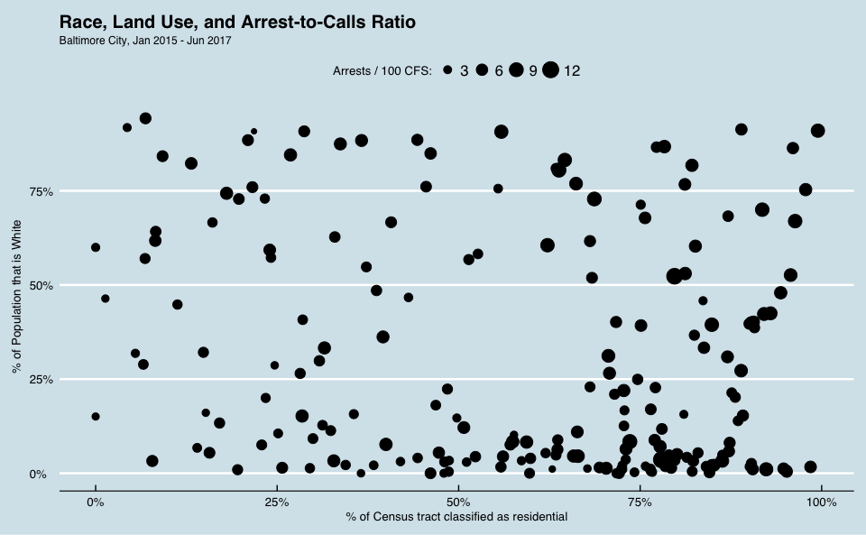

```r
ggplot(data=CensusBlockDf %>% mutate(ArrestsPerCallForService=100*ArrestsPerCallForService)) +
  geom_point(mapping=aes(x=ResidentialPercentage, y=PercentWhite, size=ArrestsPerCallForService), na.rm=TRUE) +
  scale_x_continuous(labels=percent) +
  scale_y_continuous(labels=percent) +
  scale_size_continuous(range=c(0, 6)) +
  labs(title='Race, Land Use, and Arrest-to-Calls Ratio',
       x='% of Census tract classified as residential', y='% of Population that is White',
       size='Arrests / 100 CFS:',
       subtitle=paste0('Baltimore City, ', minDateS, ' - ', maxDateS)) +
  theme_economist()
```

Finally, we examine whether a higher ratio of “urgent” calls in a Census tract correlates with a higher ratio of arrests per 100 calls. One might expect such a relationship, based on the reasoning that more urgent calls for service could be for incidents (such as robberies, burglaries, shootings, etc.) that tend to involve crimes that, in turn, lead to arrest. The data, however, tell a quite different story:

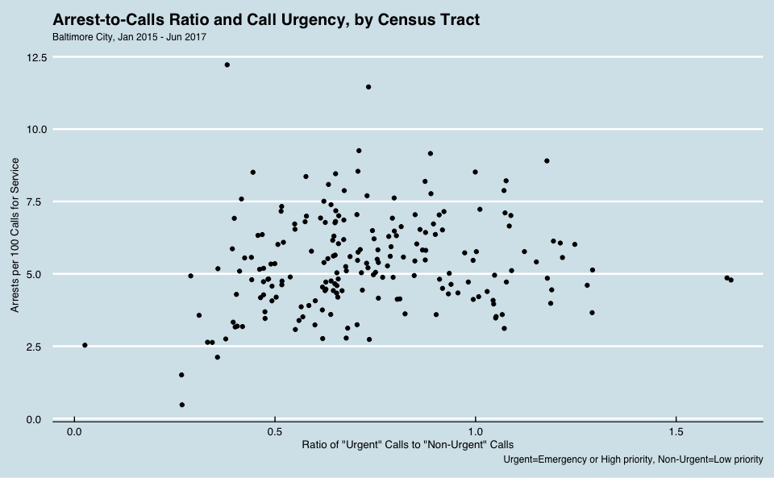

```r
ggplot(data=CensusBlockDf %>% mutate(ArrestsPerCallForService=100*ArrestsPerCallForService)) +
  geom_point(mapping=aes(x=UrgentCallRatio, y=ArrestsPerCallForService), na.rm=TRUE) +
  labs(title='Arrest-to-Calls Ratio and Call Urgency, by Census Tract',
       x='Ratio of "Urgent" Calls to "Non-Urgent" Calls', y='Arrests per 100 Calls for Service',
       subtitle=paste0('Baltimore City, ', minDateS, ' - ', maxDateS),
       caption='Urgent=Emergency or High priority, Non-Urgent=Low priority') +
  theme_economist()
```

A Pearson correlation coefficient of 0.152 here indicates a weak relationship between the variables. One possible explanation might be found in further examination of the nature of “urgent” calls. The five most frequently-occurring call descriptions, for “urgent” calls, were:

```r
sdf <- CallsForService %>% filter(priority %in% c('Emergency', 'High')) %>%
  group_by(description) %>% summarize(n=n()) %>% top_n(5, n) %>% arrange(desc(n))
writeLines(paste('* ', paste(sdf$description, comma(sdf$n), sep=': ')))
```

- Traffic Stop: 131,656
- SILENT ALARM: 70,889
- Field Interview: 31,689
- AUTO ACC/INJURY: 24,821
- RA POLICE: 24,110

Indeed, many emergency and high-priority calls with these descriptions would not necessarily lead to an arrest. Thus, it is not entirely surprising to find a weak relationship between the call urgency ratio and and the arrests-per-100 CFS measure.

## Summary

This analysis of the City of Baltimore’s Calls for Service dataset, in conjunction with its Arrest dataset, has not produced any ground-breaking conclusions. However, it does show the potential of open data initiatives to enable analysts to glean interesting information from a city’s data. We were able to discern a few not-so-surprising facts from the dataset, including:

- There is significant variation in the volume of service calls across the city, even when accounting for population density
- High-volume days and times, like July 4 and Halloween, as well as times of civil unrest, are clearly apparent in the data
- Call volume, normalized by population density, is negatively (and significantly) correlated with both median household income and residential classification
- The ratio of arrests to calls is positively correlated with residential classification and the percentage of an area that is of white race

Kudos to the City of Baltimore for making these datasets available. Like many cities across the country, including those participating in the [Police Data Initiative](https://www.policedatainitiative.org/), Baltimore has made an important commitment to transparency and community engagement by publishing rich sets of data on public safety operations.